# Karst Lab - Aspen Root Exudates

Data Analysis Notebook v2.0

Kyle Taylor

2024-08-30 15:38

# Introduction

The purpose of this notebook is to refactor the analysis completed previously by myself in Fall 2023 into a single pipeline in this markdown document. I will attempt to include all relevant communications, decisions, and references used to generate the information. The ultimate goal is that the document itself is a complete record of information used to generate the results, as well as the results themselves.

# Hypotheses

## H1.1 Sugars ~ Phenology

The higher energy that is available, the more sugars will be exuded and detected. See Analysis of H1.1.

## H1.2 Starches ~ Phenology

Starches will be detected in late season (`SENE`) rather than during peaks. See Analysis of H1.2.

## H1.3 TOC ~ Phenology

The higher energy that is available, the more C exudation will be detected. See Analysis of H1.3.

## H2.1 Colonization $\propto$ TOC

This analysis was dropped.

## H3.1 Long Ratio ~ Phenology

Root tip contact type (long versus contact) depends on C availability. In a full-leaf state, we expect higher carbon availability, and a shift to long roots. See Analysis of H3.1.

# The Data

### Primary Data

The sample and control data are stored in two seperate csv files located in the `data/raw/` folder. These tables need to be combined into a single data table for analysis, as well as calculating the control mean for each of the six sampling periods. For metadata on data table variables, see appendix S1: Variable Metadata.

```r
# Load Samples
samples <- read_csv("data/raw/23ARE_samples.csv", show_col_types = FALSE)

# Create Control Means
control_means <- read_csv("data/raw/23ARE_controls.csv", show_col_types = FALSE) %>%
  group_by(date_id) %>%
  summarise(control_TOC_mean=mean(control_TOC_raw, na.rm=T))

# Create  and Display Merged Table
aspen <- left_join(samples, control_means, by="date_id")

head(aspen)
```

| sample_id | date_id | phenology | fructose | arabitol | glucose | mannitol | sucrose | trehalose | starch | glycogen | sample_flush_vol | fine_root_mass | root_area_0_1 | root_area_1_2 | root_area_2 | root_length_0_1 | root_length_1_2 | root_length_2 | root_examined | long | contact | long_to_contact_ratio | uncolonized | colonized_root_tips | total_root_tips | root_tip_density | percent_colonization | TOC_raw | control_TOC_mean |
| --- | --- | --- | --- | --- | --- | --- | --- | --- | --- | --- | --- | --- | --- | --- | --- | --- | --- | --- | --- | --- | --- | --- | --- | --- | --- | --- | --- | --- | --- |
| S01-cuv1-D201910-SENE | D201910 | SENE | 0.0000000 | 0.2213163 | 0.2388491 | 0.0000000 | 2.216153 | 0.0843837 | 9.7518399 | 6.1092103 | 0.0370 | 24.44 | 10.5894 | 3.2115 | 0.2812 | 113.7289 | 8.0041 | 0.3776 | 30 | 21 | 14 | 1.5000000 | 7 | 35 | 42 | 1.400000 | 83.33333 | 4.823749 | 4.588013 |
| S02-cuv2-D201910-SENE | D201910 | SENE | 0.0000000 | 0.0000000 | 0.1333369 | 0.3979751 | 2.563262 | 0.0644806 | 5.3021521 | 3.3203595 | 0.0380 | 38.40 | 14.6934 | 2.3438 | 0.0939 | 148.0220 | 5.5033 | 0.1291 | 38 | 15 | 46 | 0.3260870 | 13 | 61 | 74 | 1.947368 | 82.43243 | 10.750000 | 4.588013 |
| S03-cuv3-D201910-SENE | D201910 | SENE | 0.0000000 | 0.0000000 | 0.0000000 | 0.0000000 | 0.026003 | 0.0000000 | 0.1575684 | 0.1001186 | 0.0375 | 19.51 | 5.8039 | 4.3272 | 0.0000 | 62.9134 | 11.6600 | 0.0000 | 25 | 0 | 7 | 0.0000000 | 37 | 7 | 44 | 1.760000 | 15.90909 | 6.035177 | 4.588013 |
| S04-cuv4-D201910-SENE | D201910 | SENE | NA | NA | NA | NA | NA | NA | NA | NA | 0.0205 | NA | 6.6409 | 0.7431 | 0.0000 | 74.5573 | 1.8521 | 0.0000 | 48 | 27 | 89 | 0.3033708 | 26 | 116 | 142 | 2.958333 | 81.69014 | 5.431687 | 4.588013 |
| S05-cuv5-D201910-SENE | D201910 | SENE | 0.0000000 | 0.4833033 | 0.0000000 | 1.1437885 | 3.599460 | 0.0385574 | 7.1391677 | 4.5362097 | 0.0320 | 165.80 | 17.1593 | 9.7174 | 0.1595 | 151.9035 | 21.0963 | 0.2432 | 31 | 7 | 38 | 0.1842105 | 44 | 45 | 89 | 2.870968 | 50.56180 | 5.771284 | 4.588013 |
| S06-cuv6-D201910-SENE | D201910 | SENE | 0.3291629 | 0.4155026 | 0.9346897 | 0.0000000 | 5.088583 | 0.0428808 | 10.1930961 | 6.0158646 | 0.0370 | 43.86 | 24.4643 | 8.3911 | 2.2938 | 257.0285 | 20.4946 | 2.7488 | 49 | 38 | 121 | 0.3140496 | 33 | 159 | 192 | 3.918367 | 82.81250 | 4.738939 | 4.588013 |

#### Minor Cleaning

Adding a `year` column:

```r
aspen <- aspen %>%
  mutate(year = paste0("Y",str_extract(date_id, "\\d{4}")), .after = "date_id")
```

Set factor levels for `phenology` to `(LEAF, FULL, SENE)` and set `date_id` as a factor:

```r
aspen$phenology <- factor(aspen$phenology, levels = c("LEAF", "FULL", "SENE"))
aspen$date_id <- factor(aspen$date_id)
```

### Derived Data

#### Standardized Total Organic Carbon

The existing `c_conc` variable is in mg/L, so this needs to be:

1. Corrected by the sampling date group mean of the control blanks TOC concentration
2. Standardized by the sample mass and flush volume.

The formula for our new mass fraction variable, `exudate_ratio` is then:

$$\text{exudate_ratio}=\frac{\text{(TOC_raw}-\text{control_TOC_mean)}*\text{sample_flush_vol}}{\text{fine_root_mass}}*\frac{1000
\mu g}{mg}$$

Applying this formula to the datatable:

```r
aspen <- aspen %>%
  mutate(exudate_ratio = (TOC_raw - control_TOC_mean)*sample_flush_vol/fine_root_mass*1000)
```

#### All Sugars

**all_sugars** is defined as the sum of the concentrations of all fungal and tree sugars: **fructose, arabitol, glucose, mannitol, sucrose,** and **trehalose**. Units are $\mu\text{g/mg}$.

```r
aspen <- aspen %>%
  rowwise() %>%
  mutate(all_sugars = sum(c_across(fructose:trehalose)), .after="trehalose") %>% ungroup()
```

#### Root Tip Proportion Variables

```r
aspen <- aspen %>%
  rename(colonized=colonized_root_tips) %>%
  mutate(colonized_p = colonized/total_root_tips,
         uncolonized_p = uncolonized/total_root_tips,
         contact_p = contact/total_root_tips,
         long_p = long/total_root_tips,
         contact_ratio = contact_p/colonized_p,
         long_ratio = long_p/colonized_p,
         .after = "total_root_tips")
```

### Export and Archive

Archive the prepared data table in both .csv and .Rdata formats for future use. The RDS data file will be the canonical data table called by the `getAspen()` function for all future analysis.

```r
write_csv(aspen, "data/processed/23ARE_datatable.csv")
saveRDS(aspen, "data/processed/23ARE_datatable.rds")
```

# Analysis

## Analysis of H1.1

**Goal:** To compare total sugars between different `phenology` states while accounting for random variation between years.

### EDA

Exploring the data groupings through box-plots:

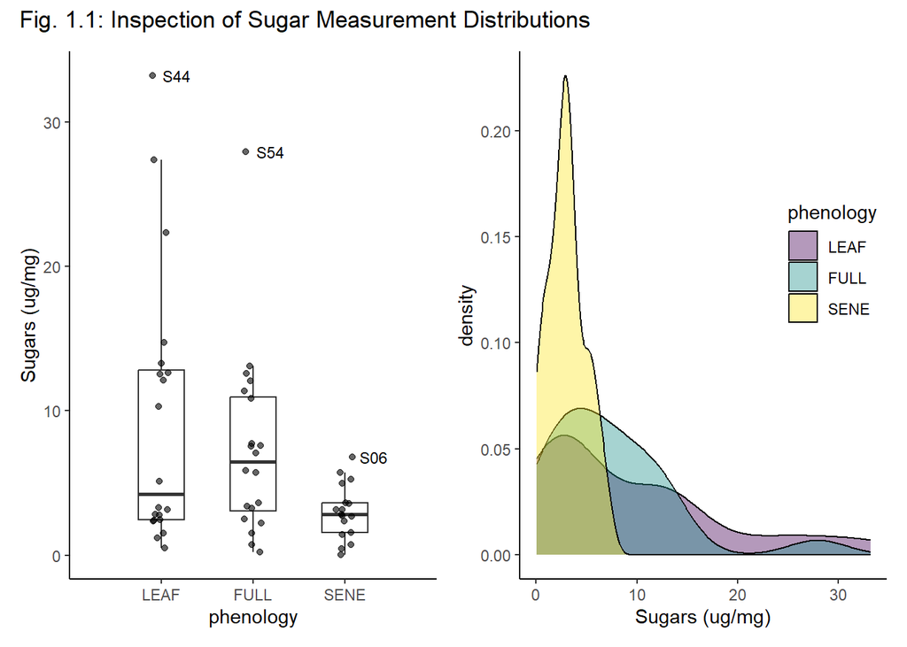

```r
p1 <- getAspen() %>%
  group_by(phenology) %>%
  label_outliers(all_sugars, sample_id) %>%
  ungroup() %>%
  mutate(label = substr(label, 1, 3)) %>%
  ggplot(aes(x=phenology, y=all_sugars)) +
  geom_boxplot(width=0.5, outliers = FALSE) +
  geom_jitter(alpha=0.6, width = 0.1) +
  geom_text(aes(label=label), na.rm=TRUE, size = 3, hjust=-0.3, position=position_jitter(width = 0.1)) +
  scale_x_discrete(expand = c(0,1)) +
  cleangg() +
  labs(y="Sugars (ug/mg)")
p2 <- getAspen() %>%
  ggplot(aes(x=all_sugars)) +
  facet_wrap(vars(phenology)) +
  geom_histogram(binwidth=5) +
  cleangg()
p3 <- getAspen() %>%
  ggplot(aes(x=all_sugars)) +
  geom_density(aes(fill=phenology), alpha=0.4) +
  cleangg() +
  theme(legend.position = "inside",
        legend.position.inside = c(0.85,0.6)) +
  scale_fill_viridis_d(option="D") +
  labs(x="Sugars (ug/mg)")
p1+p3+plot_annotation(title="Fig. 1.1: Inspection of Sugar Measurement Distributions")
```

The groups all show differences in their means, variance, and distribution shape, with none appearing normally distributed. Each phenology grouping contains one upper outlier outside the 1.5IQR. In particular, the `FULL` group contains a *far outlier* (as defined in (Tukey 1977)), sample `S54`, which is 2.14IQR outside the upper hinge.

Fitting to a linear model and inspecting the variance of the residuals gives:

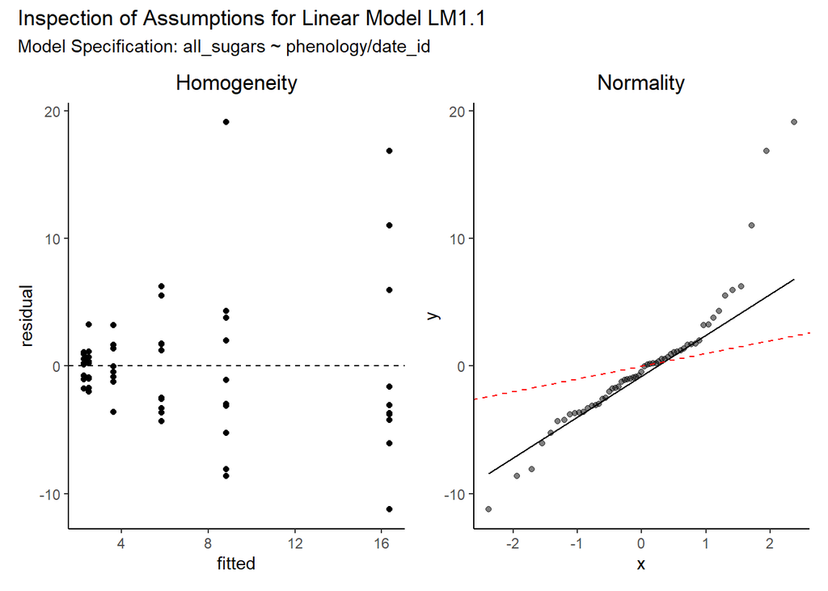

```r
h1.1.lm <- lm(all_sugars ~ phenology/date_id, data=getAspen())
p1 <- tibble(fitted = fitted(h1.1.lm),
       residual = residuals(h1.1.lm)) %>%
  ggplot(aes(x=fitted, y=residual)) +
  geom_point() +
  cleangg() +
  labs(title = "Homogeneity") +
  geom_hline(yintercept = 0, linetype = "dashed")
p2 <- tibble(residual = residuals(h1.1.lm)) %>%
  ggplot(aes(sample=residual)) +
  geom_qq(alpha=0.5) +
  geom_qq_line() +
  geom_abline(intercept=0, slope = 1, linetype="dashed", colour="red") +
  cleangg() +
  labs(title = "Normality")
p1 + p2 + plot_annotation(title = "Inspection of Assumptions for Linear Model LM1.1",
                          subtitle = "Model Specification: all_sugars ~ phenology/date_id")
```

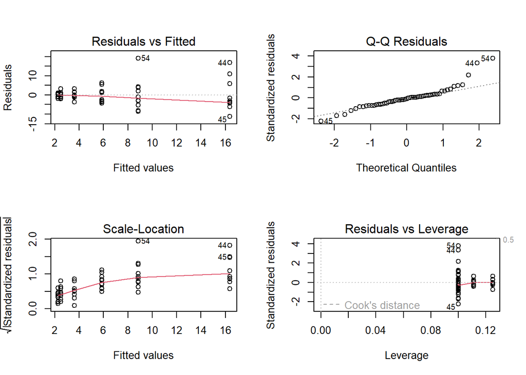

```r
op <- par(mfrow = c(2,2))
plot(h1.1.lm)
```

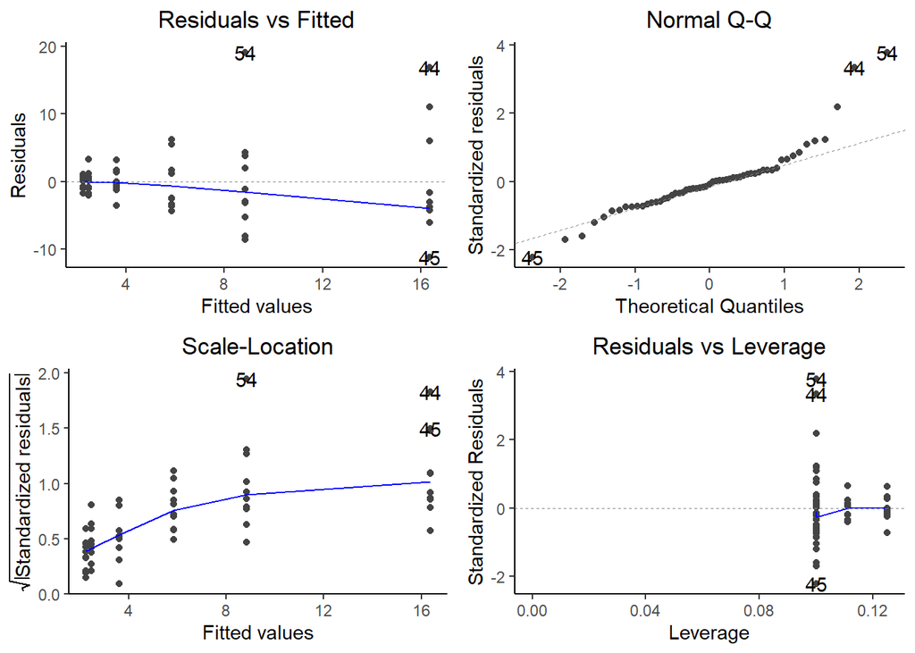

```r
par(op)
autoplot(h1.1.lm) +
  cleangg()
```

Group means were calculated without considering date as a random factor (year to year variation excluded). This gives the following result plot with 95% confidence intervals:

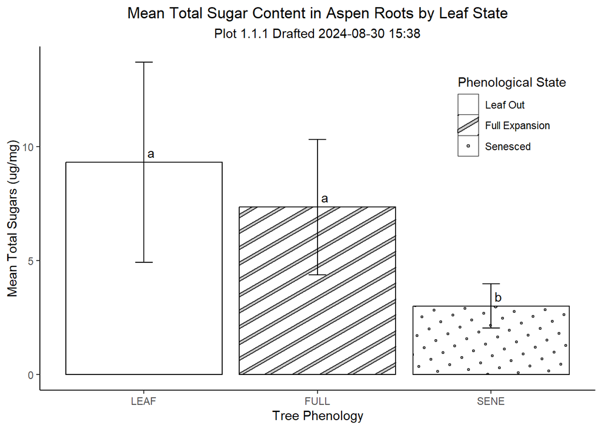

Testing for significance, we must first consider homogeneity of variance:

```r
getAspen() %>%
  group_by(phenology) %>%
  summarise(mean = mean(all_sugars, na.rm=TRUE),
            variance = var(all_sugars, na.rm=TRUE))
```

| phenology | mean | variance |
| --- | --- | --- |
| LEAF | 9.310586 | 87.598041 |
| FULL | 7.344753 | 40.327984 |
| SENE | 3.014581 | 3.566914 |

The variances are very unequal, so we select Games-Howell *post hoc* test which does not require this assumption.

```r
games_howell_test(getAspen(), all_sugars ~ phenology, conf.level = 0.95)
```

| .y. | group1 | group2 | estimate | conf.low | conf.high | p.adj | p.adj.signif |
| --- | --- | --- | --- | --- | --- | --- | --- |
| all_sugars | LEAF | FULL | -1.965834 | -8.167944 | 4.2362772 | 0.719 | ns |
| all_sugars | LEAF | SENE | -6.296005 | -11.699708 | -0.8923018 | 0.021 | * |
| all_sugars | FULL | SENE | -4.330171 | -8.068255 | -0.5920879 | 0.021 | * |

Without consideration of inter-annual variation, there is a significant difference in mean sugar content between senescent and non-senescent samples.

### Model

Incorporating the `date_id` as a random factor into a Linear Mixed Model (LMM) to assess the impact of yearly variation:

```r
emmeans((lmer(all_sugars ~ phenology + (1 | date_id:phenology),
              data = getAspen())), ~phenology) %>%
  pairs()
```

```
##  contrast    estimate   SE   df t.ratio p.value
##  LEAF - FULL     1.97 5.92 2.97   0.332  0.9422
##  LEAF - SENE     6.27 5.94 3.01   1.055  0.5985
##  FULL - SENE     4.30 5.94 3.01   0.724  0.7681
##
## Degrees-of-freedom method: kenward-roger
## P value adjustment: tukey method for comparing a family of 3 estimates
```

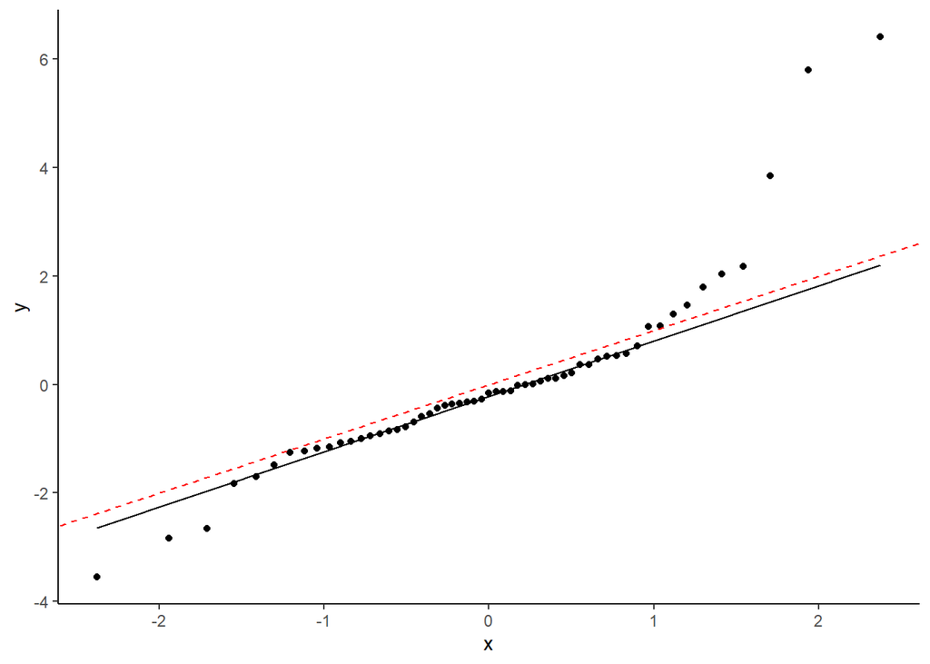

```r
residuals(lmer(all_sugars^1/3 ~ phenology + (1 | date_id:phenology),
              data = getAspen())) %>% as_tibble() %>%
  ggplot(aes(sample=value)) +
  geom_qq() +
  geom_qq_line() +
  geom_abline(slope =1, color="red", linetype = "dashed") +
  theme(panel.grid.major = element_line(color = "grey", size = 0.5),
        panel.grid.minor = element_line(color = "grey", size=0.25)) +
  cleangg()
```

Estimated pairwise contrasts of means are not significantly different.

### Nested ANOVA

Fitting a nested ANOVA model with the following structure:

**All Sugars ~ Phenology / Sample Date**

```r
h1.1.model <- lm(all_sugars ~ phenology/date_id, data = getAspen())
result <- summary(aov(h1.1.model))
effect_size <- result[[1]]$`Sum Sq` / sum(result[[1]]$`Sum Sq`)
result[[1]]$`Effect Size` <- effect_size
as_tibble(result[[1]]) %>% mutate(across(Df:`F value`, round, digits=2))
```

| Df | Sum Sq | Mean Sq | F value | Pr(>F) | Effect Size |
| --- | --- | --- | --- | --- | --- |
| 2 | 375.41 | 187.71 | 6.64 | 0.0027415 | 0.1311215 |
| 3 | 1045.40 | 348.47 | 12.32 | 0.0000035 | 0.3651311 |
| 51 | 1442.27 | 28.28 | NA | NA | 0.5037474 |

But we need to be cautious about this result because we have an unbalanced design due missing values in data collection:

```r
balance("all_sugars", "phenology", "date_id")
```

```
##
##        D201910 D202005 D202007 D202009 D202105 D202107
##   LEAF       0      10       0       0      10       0
##   FULL       0       0      10       0       0      10
##   SENE       8       0       0       9       0       0
```

#### Test of ANOVA Assumptions

To test ANOVA assumptions, we should look at the normality of the residuals of the fitted model:

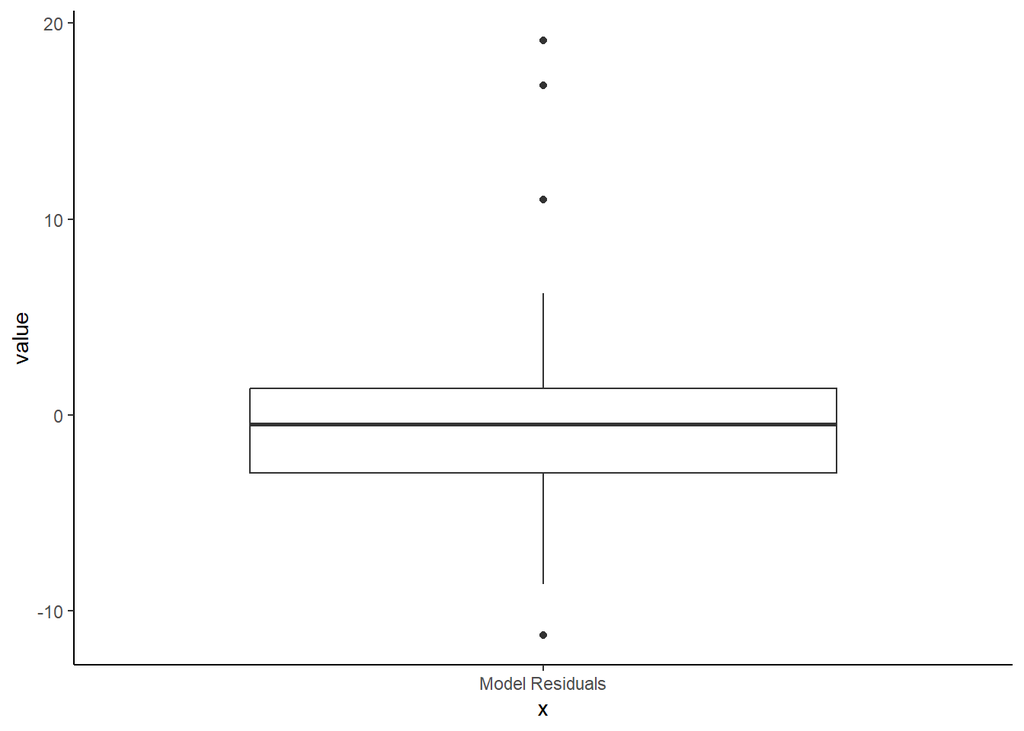

```r
residuals(h1.1.model) %>% as_tibble() %>%
  ggplot(aes(x="Model Residuals", y=value)) +
  geom_boxplot() +
  cleangg()
```

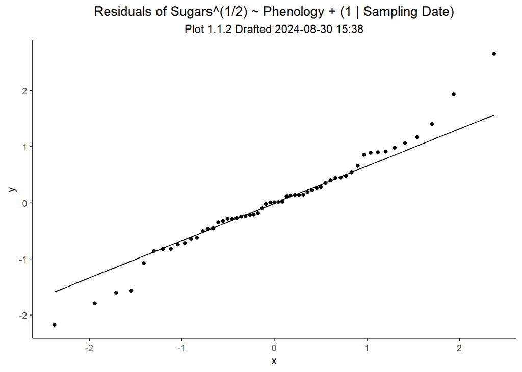

```r
tibble(phenology = getAspen() %>% filter(!is.na(all_sugars)) %>% pull(phenology),
     residual = residuals(lmer(all_sugars^(0.5) ~ phenology + (1 | date_id:phenology), data = getAspen()))) %>%
  ggplot() +
  geom_qq(aes(sample=residual)) +
  geom_qq_line(aes(sample=residual)) +
  cleangg() +
  labs(title = "Residuals of Sugars^(1/2) ~ Phenology + (1 | Sampling Date)",
       subtitle = watermark("1.1.2"))
```

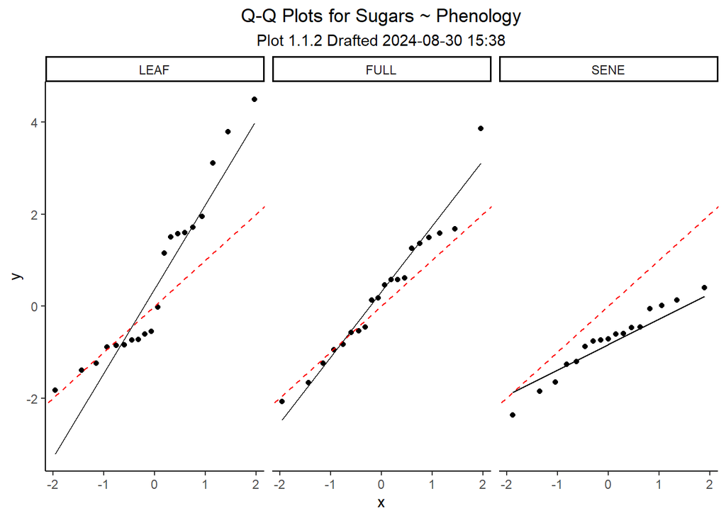

```r
getAspen() %>%
  ggplot(aes(sample=(all_sugars)^(1/1.8)-2.5)) +
  stat_qq(aes(group = phenology)) +
  stat_qq_line() +
  geom_abline(slope=1, intercept = 0, color = "red", linetype="dashed") +
  facet_wrap(vars(phenology)) +
  theme_classic() +
  labs(title = "Q-Q Plots for Sugars ~ Phenology",
       subtitle = watermark("1.1.2")) +
  theme(plot.title = element_text(hjust=0.5),
        plot.subtitle = element_text(hjust=0.5))
```

### Non-Parametric Tests

Assuming we know nothing about the distributions of the different phenology groupings, and due to the violations of assumptions apparent in the ANOVA, can we make observations about the direction of medians between `phenology` levels?

#### Kruskal-Wallace Test

```r
getAspen() %>%
  kruskal.test(all_sugars ~ phenology, data = .)
```

```
##
##  Kruskal-Wallis rank sum test
##
## data:  all_sugars by phenology
## Kruskal-Wallis chi-squared = 6.2263, df = 2, p-value = 0.04446
```

This indicates at least one group differs from the others. Performing a pairwise wilcox test with bonferroni correction:

```r
pairwise.wilcox.test(getAspen()$all_sugars, getAspen()$phenology, p.adjust.method = "bonferroni")
```

```
##
##  Pairwise comparisons using Wilcoxon rank sum exact test
##
## data:  getAspen()$all_sugars and getAspen()$phenology
##
##      LEAF  FULL
## FULL 1.000 -
## SENE 0.208 0.032
##
## P value adjustment method: bonferroni
```

### Summary of Results

Testing without considering sampling date as a random factor produced significant differences between groups. However, when fitting to a LMM with sampling date as a nested random effect inside phenology, these differences were no longer apparent. Differences between the two years sampled are larger than the differences between phenology states.

## Analysis of H1.2

**Goal:** To compare total starches between different `phenology` states while considering random annual variation.

### EDA

Initial exploration of the data:

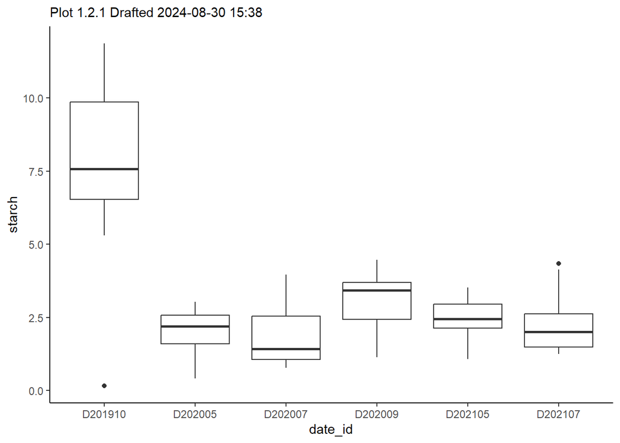

```r
getAspen() %>%
  ggplot(aes(x=date_id, y=starch)) +
  geom_boxplot() +
  theme_classic() +
  labs(subtitle = watermark("1.2.1"))
```

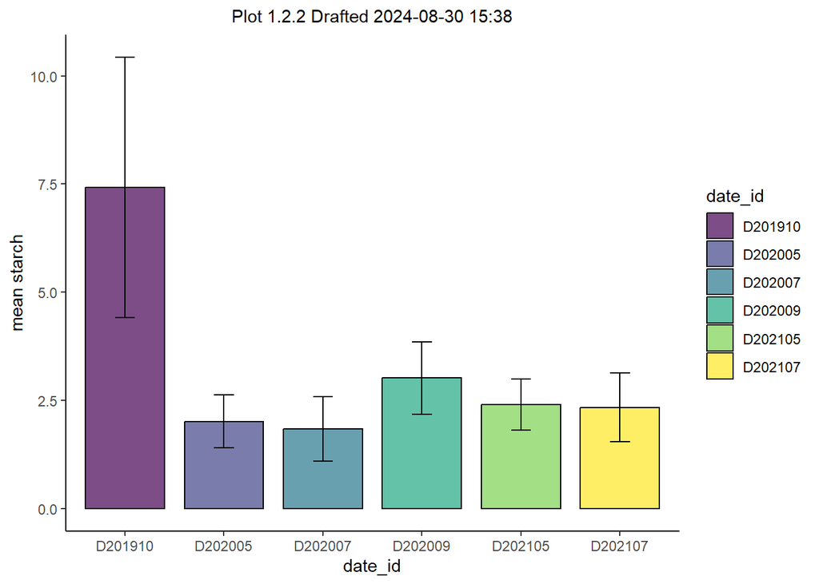

```r
mean_n_se_ci(getAspen(), "date_id", "starch", 0.95) %>%
  ggplot(aes(x = date_id, y = mean_starch, fill = date_id)) +
  geom_col(color="black", width=.8) +
  geom_errorbar(aes(ymax=upper95, ymin=lower95), width=0.2) +
  theme_classic() +
  scale_fill_manual(values=viridis(n=6, option="D", alpha=0.7))+
  labs(y="mean starch",
       subtitle = watermark("1.2.2")) +
  theme(plot.subtitle = element_text(hjust = 0.5))
```

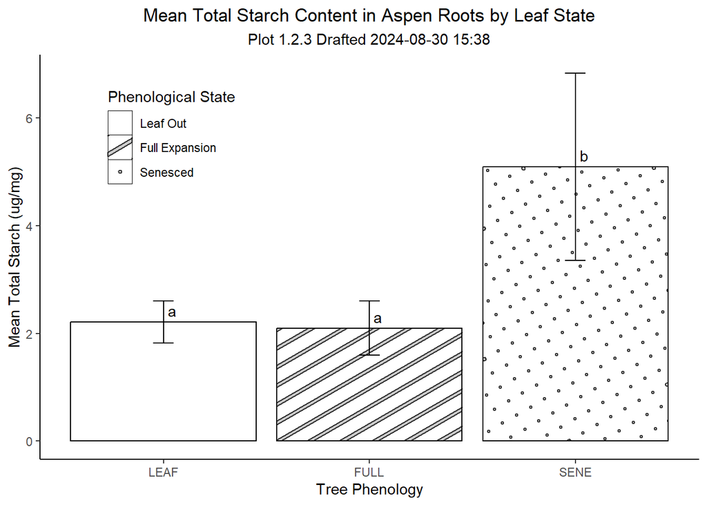

```r
mean_n_se_ci(getAspen(), "phenology", "starch", 0.95) %>%
  ggplot(aes(x=phenology, y = mean_starch, pattern=phenology)) +
   geom_col_pattern(fill='white',colour='black',
    pattern_density = 0.2,
    pattern_spacing = 0.04,
    pattern_key_scale_factor = 1) +
  geom_errorbar(aes(ymin=lower95,ymax=upper95), width = 0.1) +
  geom_text(label=c("a","a","b"), hjust = -0.5, vjust=-0.5) +
  theme_classic() +
  theme(plot.title = element_text(hjust=0.5),
        plot.subtitle = element_text(hjust=0.5),
        legend.position = c(0.2, 0.8)) +
  labs(title = "Mean Total Starch Content in Aspen Roots by Leaf State",
       subtitle = watermark("1.2.3"),
       x = "Tree Phenology",
       y = "Mean Total Starch (ug/mg)",
       pattern = c("Phenological State")) +
  scale_pattern_manual(values=c("none","stripe","circle"),
                       labels = c("Leaf Out", "Full Expansion", "Senesced"))
```

Given the strong variation between years shown in plot 1.2.1, and the findings in **H1.1**, we know that it is likely we need to consider date as a random effect in the model.

### Model

```r
emmeans(lmer(starch ~ phenology + (1 | date_id:phenology), data=getAspen()), ~phenology) %>%
  pairs()
```

```
##  contrast    estimate   SE   df t.ratio p.value
##  LEAF - FULL    0.116 1.79 2.97   0.065  0.9977
##  LEAF - SENE   -2.996 1.80 3.01  -1.664  0.3495
##  FULL - SENE   -3.112 1.80 3.01  -1.729  0.3297
##
## Degrees-of-freedom method: kenward-roger
## P value adjustment: tukey method for comparing a family of 3 estimates
```

The differences between groups are in the predicted direction with a $\approx 3\mu$g/mg difference between scenesced samples and both other states, but are not significantly different when accounting for annual variation.

### Nested ANOVA

```r
balance("starch", "phenology", "date_id")
```

```
##
##        D201910 D202005 D202007 D202009 D202105 D202107
##   LEAF       0      10       0       0      10       0
##   FULL       0       0      10       0       0      10
##   SENE       8       0       0       9       0       0
```

```r
result <- summary(aov(starch ~ phenology/date_id, data = getAspen()))
effect_size <- result[[1]]$`Sum Sq` / sum(result[[1]]$`Sum Sq`)
result[[1]]$`Effect Size` <- effect_size
result
```

```
##                   Df Sum Sq Mean Sq F value    Pr(>F) Effect Size
## phenology          2 103.04   51.52   19.66 4.670e-07      0.3213
## phenology:date_id  3  84.02   28.01   10.69 1.462e-05      0.2620
## Residuals         51 133.61    2.62                        0.4167
## 3 observations deleted due to missingness
```

```r
as_tibble(result[[1]]) %>% select(-"Effect Size") %>% mutate(across(Df:`F value`, round, digits=2))
```

[output not shown]

Should we be cautious with this result? The study is unbalanced:

```r
balance("starch","phenology","date_id")
```

```
##
##        D201910 D202005 D202007 D202009 D202105 D202107
##   LEAF       0      10       0       0      10       0
##   FULL       0       0      10       0       0      10
##   SENE       8       0       0       9       0       0
```

To estimate sensitivity to the balance, I repeatedly re-sampled 8 from each group to balance the design and reran the ANOVA:

```r
set.seed(123) # for reproducibility. Removing this line will allow the following code to change pseudo-randomly every time it is run.
getAspen() %>%
  group_by(phenology, date_id) %>%
  slice_sample(n=8) %>%
  ungroup() %>%
  aov(starch ~ phenology/date_id, data = .) %>%
  summary()
```

```
##                   Df Sum Sq Mean Sq F value   Pr(>F)
## phenology          2  64.15   32.07  10.537 0.000219 ***
## phenology:date_id  3  56.75   18.92   6.215 0.001487 **
## Residuals         39 118.71    3.04
## ---
## Signif. codes:  0 '***' 0.001 '**' 0.01 '*' 0.05 '.' 0.1 ' ' 1
## 3 observations deleted due to missingness
```

Re-sampling this repeatedly doesn’t significantly change the magnitude or p-value. This seems to indicate that the imbalance is not the main driver of the result.

#### Test of ANOVA Assumptions

##### Normality

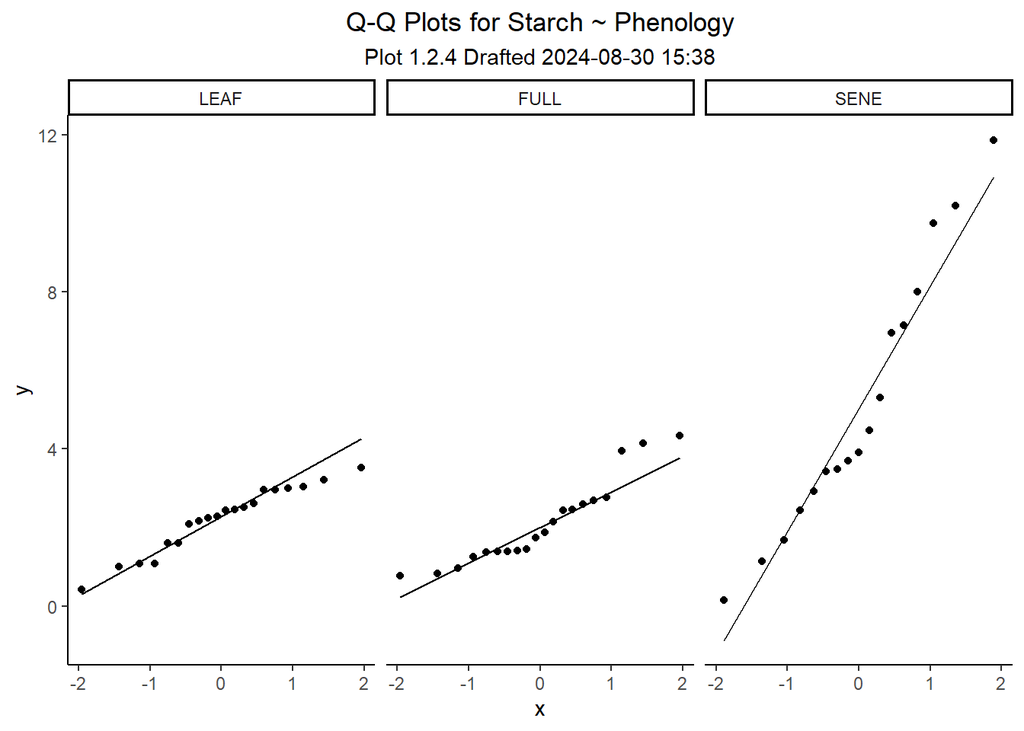

```r
aspenQQ(starch, phenology, "Q-Q Plots for Starch ~ Phenology", "1.2.4")
```

This shows that all three distributions do not appear to significantly depart from normality.

##### Equality of Variances

```r
getAspen() %>%
  levene_test(starch ~ phenology/date_id)
```

| df1 | df2 | statistic | p |
| --- | --- | --- | --- |
| 5 | 51 | 3.815536 | 0.0051799 |

Levene’s test indicates that the variances between groups differ significantly, violating ANOVA assumptions

### Summary of Results

Starches were generally higher in the when trees were sampled in the senesced state, but variation between years was much higher than between phenology contrasts. The lack of control on this inter-annual variation means that the differences detected between phenology states highly variable and statistically non-significant at p=0.05 when adjusted for multiple tests.

## H2.1 Exudate Ratio X Percent Colonization

```r
erpcaov <- lm(exudate_ratio ~ colonized_p + date_id, data=getAspen())
summary(aov(erpcaov))
```

```
##             Df Sum Sq Mean Sq F value Pr(>F)
## colonized_p  1   0.08   0.080   0.032 0.8595
## date_id      5  32.87   6.574   2.593 0.0367 *
## Residuals   50 126.78   2.536
## ---
## Signif. codes:  0 '***' 0.001 '**' 0.01 '*' 0.05 '.' 0.1 ' ' 1
## 3 observations deleted due to missingness
```

## Analysis of H1.3

**Goal:** To model `exudate_ratio` as a function of `phenology` and the random effect of `date_id`

### EDA

First to explore the variance in `date_id`:

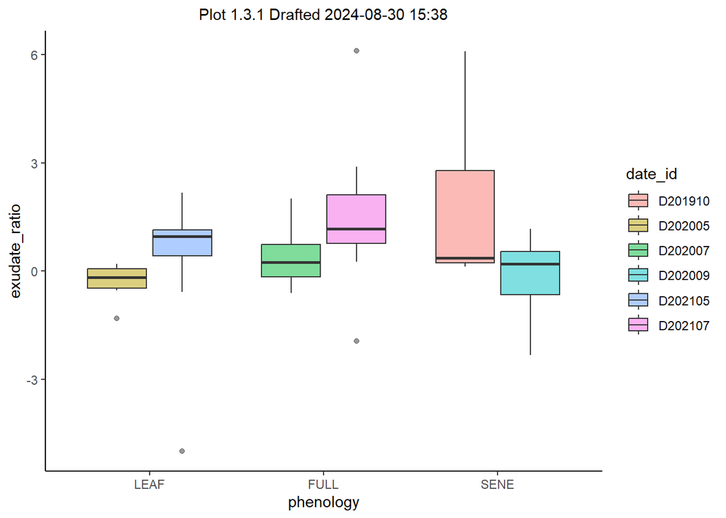

```r
ggplot(getAspen(), aes(x=phenology, y=exudate_ratio, fill=date_id)) +
  geom_boxplot(alpha=0.5) +
  theme_classic() +
  theme(plot.title = element_text(hjust=0.5),
        plot.subtitle = element_text(hjust=0.5)) +
  labs(subtitle = watermark("1.3.1"))
```

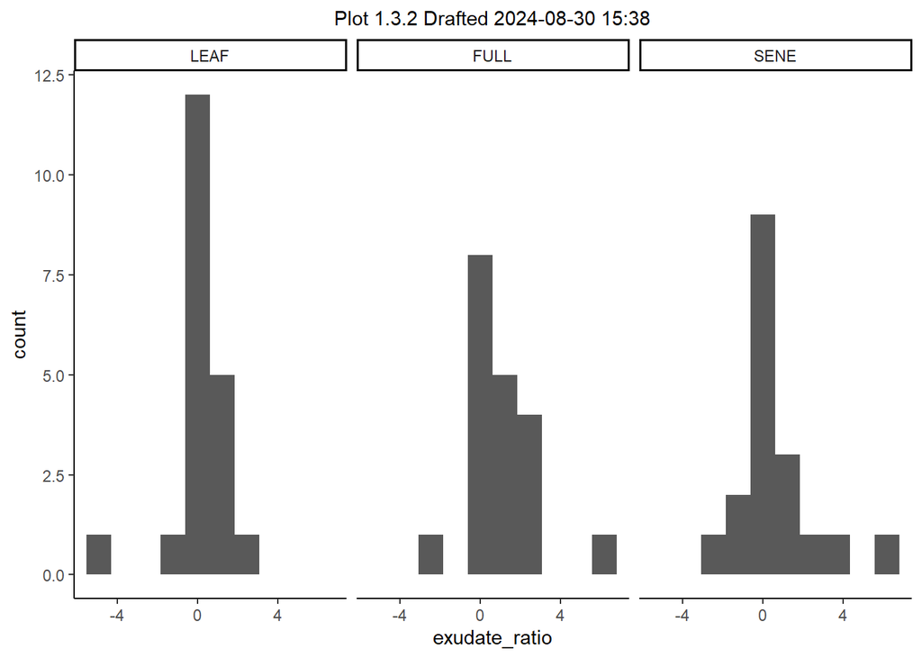

```r
ggplot(getAspen(), aes(x=exudate_ratio)) +
  geom_histogram(bins = 10) +
  facet_wrap(~phenology) +
  theme_classic() +
  theme(plot.subtitle = element_text(hjust=0.5)) +
  labs(subtitle = watermark("1.3.2"))
```

And now within-group variance?

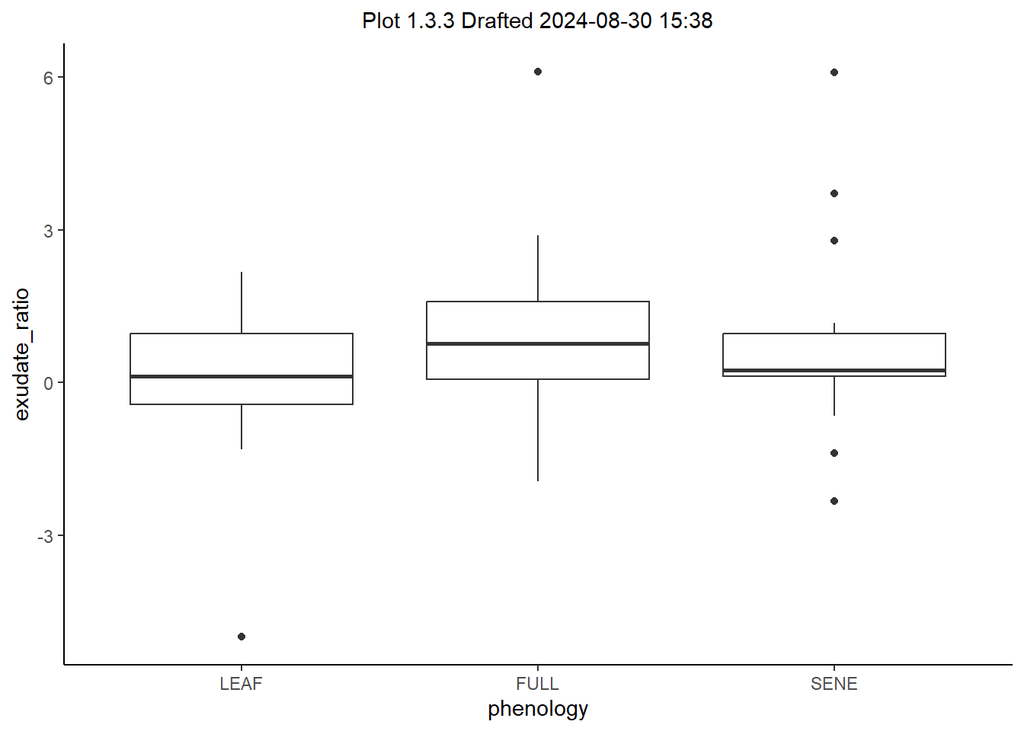

```r
ggplot(getAspen(), aes(x=phenology, y=exudate_ratio)) +
  geom_boxplot() +
  theme_classic() +
  theme(plot.subtitle = element_text(hjust=0.5)) +
  labs(subtitle = watermark("1.3.3"))
```

Spread seems to be a little bigger in `SENE` but acceptable.

### Model

```r
emmeans(lmer(exudate_ratio ~ phenology + (1 | date_id:phenology), data=getAspen()), ~phenology) %>%
  pairs()
```

```
##  contrast    estimate    SE   df t.ratio p.value
##  LEAF - FULL   -0.959 0.909 2.95  -1.056  0.5990
##  LEAF - SENE   -0.732 0.912 3.00  -0.802  0.7276
##  FULL - SENE    0.227 0.916 3.05   0.248  0.9670
##
## Degrees-of-freedom method: kenward-roger
## P value adjustment: tukey method for comparing a family of 3 estimates
```

### Nested ANOVA

```r
balance("exudate_ratio", "phenology", "date_id")
```

```
##
##        D201910 D202005 D202007 D202009 D202105 D202107
##   LEAF       0      10       0       0      10       0
##   FULL       0       0      10       0       0       9
##   SENE       9       0       0       9       0       0
```

```r
result <- summary(aov(exudate_ratio ~ phenology/date_id, data = getAspen()))
effect_size <- result[[1]]$`Sum Sq` / sum(result[[1]]$`Sum Sq`)
result[[1]]$`Effect Size` <- effect_size
result
```

```
##                   Df Sum Sq Mean Sq F value  Pr(>F) Effect Size
## phenology          2   9.48   4.740   1.907 0.15904      0.0594
## phenology:date_id  3  23.44   7.813   3.142 0.03307      0.1467
## Residuals         51 126.81   2.486                      0.7939
## 3 observations deleted due to missingness
```

```r
as_tibble(result[[1]]) %>% select(-"Effect Size") %>% mutate(across(Df:`F value`, round, digits=2))
```

| Df | Sum Sq | Mean Sq | F value | Pr(>F) |
| --- | --- | --- | --- | --- |
| 2 | 9.48 | 4.74 | 1.91 | 0.1590402 |
| 3 | 23.44 | 7.81 | 3.14 | 0.0330661 |
| 51 | 126.81 | 2.49 | NA | NA |

### Summary of Results

No relationship was found between `exudate_ratio` and `phenology`.

## Analysis of H3.1

### EDA

Inspecting variance between `phenology` groups:

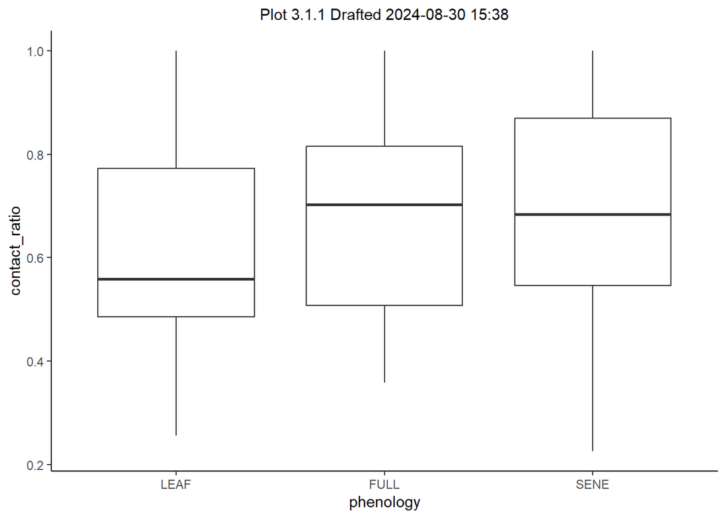

```r
getAspen() %>%
  ggplot(aes(x=phenology, y=contact_ratio)) +
  geom_boxplot() +
  theme_classic() +
  theme(plot.subtitle = element_text(hjust=0.5)) +
  labs(subtitle = watermark("3.1.1"))
```

Between group variance and normality looks reasonable. Between `date_id` groupings?

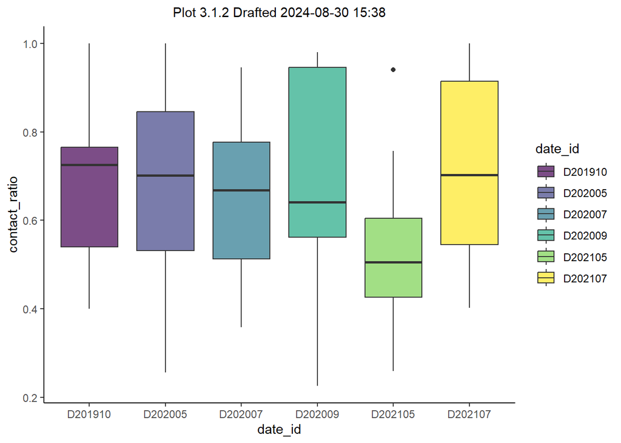

```r
getAspen() %>%
  ggplot(aes(x=date_id, y=contact_ratio, fill=date_id)) +
  geom_boxplot() +
  theme_classic() +
  theme(plot.subtitle = element_text(hjust=0.5)) +
  labs(subtitle = watermark("3.1.2")) +
  scale_fill_manual(values=viridis(n=6, option="D", alpha=0.7))
```

Reasonable with note on `D202105`.

Checking for outliers greater than 3 Inter-Quartile Range (3IQR):

```r
for (i in unique (getAspen()$date_id)) {
  print(paste("Outliers for group ", i))
  getAspen() %>% filter(date_id == i) %>%
    rm_outlier_3IQR("contact_ratio")
}
```

```
## [1] "Outliers for group  D201910"
## [1] "Lower Bound:  -0.138180825355516"
## [1] "Upper Bound:  1.44358018093379"
## [1] "No outliers identified."
## [1] "Outliers for group  D202005"
## [1] "Lower Bound:  -0.410714285714285"
## [1] "Upper Bound:  1.78720238095238"
## [1] "No outliers identified."
## [1] "Outliers for group  D202007"
## [1] "Lower Bound:  -0.279492309477885"
## [1] "Upper Bound:  1.56881746132632"
## [1] "No outliers identified."
## [1] "Outliers for group  D202009"
## [1] "Lower Bound:  -0.588848463848464"
## [1] "Upper Bound:  2.09638484638485"
## [1] "No outliers identified."
## [1] "Outliers for group  D202105"
## [1] "Lower Bound:  -0.106789577699189"
## [1] "Upper Bound:  1.1377509361348"
## [1] "No outliers identified."
## [1] "Outliers for group  D202107"
## [1] "Lower Bound:  -0.561120449418322"
## [1] "Upper Bound:  2.02094428716769"
## [1] "No outliers identified."
```

No outliers within date groups.

### Model

**LMM**

```r
summary(lmer(contact_ratio ~ phenology + (1 | date_id:phenology), data=getAspen()))
```

```
## boundary (singular) fit: see help('isSingular')
```

```
## Linear mixed model fit by REML. t-tests use Satterthwaite's method [
## lmerModLmerTest]
## Formula: contact_ratio ~ phenology + (1 | date_id:phenology)
##    Data: getAspen()
##
## REML criterion at convergence: -2.5
##
## Scaled residuals:
##     Min      1Q  Median      3Q     Max
## -2.0860 -0.7538  0.0030  0.7861  1.7911
##
## Random effects:
##  Groups            Name        Variance Std.Dev.
##  date_id:phenology (Intercept) 0.00000  0.0000
##  Residual                      0.04788  0.2188
## Number of obs: 60, groups:  date_id:phenology, 6
##
## Fixed effects:
##               Estimate Std. Error       df t value Pr(>|t|)
## (Intercept)    0.60808    0.04893 57.00000  12.428   <2e-16 ***
## phenologyFULL  0.07139    0.06919 57.00000   1.032    0.307
## phenologySENE  0.07416    0.06919 57.00000   1.072    0.288
## ---
## Signif. codes:  0 '***' 0.001 '**' 0.01 '*' 0.05 '.' 0.1 ' ' 1
##
## Correlation of Fixed Effects:
##             (Intr) phFULL
## phenlgyFULL -0.707
## phenlgySENE -0.707  0.500
## optimizer (nloptwrap) convergence code: 0 (OK)
## boundary (singular) fit: see help('isSingular')
```

Appears to overfit data due to lack of variation in sampling date factor. This suggest we should simplify to linear model with no date factor.

**Linear Model**

```r
summary(lm(contact_ratio ~ phenology, data=getAspen()))
```

```
##
## Call:
## lm(formula = contact_ratio ~ phenology, data = getAspen())
##
## Residuals:
##      Min       1Q   Median       3Q      Max
## -0.45644 -0.16493  0.00066  0.17201  0.39192
##
## Coefficients:
##               Estimate Std. Error t value Pr(>|t|)
## (Intercept)    0.60808    0.04893  12.428   <2e-16 ***
## phenologyFULL  0.07139    0.06919   1.032    0.307
## phenologySENE  0.07416    0.06919   1.072    0.288
## ---
## Signif. codes:  0 '***' 0.001 '**' 0.01 '*' 0.05 '.' 0.1 ' ' 1
##
## Residual standard error: 0.2188 on 57 degrees of freedom
## Multiple R-squared:  0.02525,    Adjusted R-squared:  -0.008953
## F-statistic: 0.7382 on 2 and 57 DF,  p-value: 0.4825
```

### Summary of Results

Phenology was not a good predictor of the contact ratio, even without accounting for annual variation.

# Draft Revisions

## Results

### LN 233-235 - Sucrose

Need to know ratio of sucrose to the next highest sugar.

```r
getAspen() %>%
  select(fructose:trehalose) %>%
  summarize(across(everything(), mean, na.rm = TRUE)) %>%
  mutate(sucrose_glucose_ratio = sucrose / glucose) %>%
  select(sucrose_glucose_ratio)
```

| sucrose_glucose_ratio |
| --- |
| 2.384654 |

### LN 237-238 - Sugar Summary

Mean, range, and SE of total sugars:

```r
mean(getAspen()$all_sugars, na.rm = TRUE) %>%
  round(digits=2) %>%
  paste("Mean =", .)
```

```
## [1] "Mean = 6.74"
```

```r
range(getAspen()$all_sugars, na.rm = TRUE) %>%
  round(digits = 2) %>%
  paste("Range =", .)
```

```
## [1] "Range = 0.03"  "Range = 33.21"
```

```r
se(getAspen()$all_sugars) %>%
  round(digits = 2) %>%
  paste("SE =", .)
```

```
## [1] "SE = 0.95"
```

### LN 240-241 - Starch Summary

Mean, range, and SE of total starch:

```r
mean(getAspen()$starch, na.rm = TRUE) %>%
  round(digits=2) %>%
  paste("Mean =", .)
```

[1] “Mean = 3.03”

```r
range(getAspen()$starch, na.rm = TRUE) %>%
  round(digits = 2) %>%
  paste("Range =", .)
```

[1] “Range = 0.16” “Range = 11.87”

```r
se(getAspen()$starch) %>%
  round(digits = 2) %>%
  paste("SE =", .)
```

[1] “SE = 0.32”

### LN 243-244 - Exudate Ratio Summary

Mean, range, and SE of Exudate Rate:

```r
mean(getAspen()$exudate_ratio, na.rm = TRUE) %>%
  round(digits=2) %>%
  paste("Mean =", .)
```

```
## [1] "Mean = 0.56"
```

```r
range(getAspen()$exudate_ratio, na.rm = TRUE) %>%
  round(digits = 2) %>%
  paste("Range =", .)
```

```
## [1] "Range = -5"   "Range = 6.11"
```

```r
se(getAspen()$exudate_ratio) %>%
  round(digits = 2) %>%
  paste("SE =", .)
```

```
## [1] "SE = 0.22"
```

### LN 256-257 - Long-to-Contact Ratio Summary

Mean, range, and SE of Long-to-Contact Ratio:

```r
mean(getAspen()$long_to_contact_ratio, na.rm = TRUE) %>%
  round(digits=2) %>%
  paste("Mean =", .)
```

```
## [1] "Mean = 0.75"
```

```r
range(getAspen()$long_to_contact_ratio, na.rm = TRUE) %>%
  round(digits = 2) %>%
  paste("Range =", .)
```

```
## [1] "Range = 0"    "Range = 3.43"
```

```r
se(getAspen()$long_to_contact_ratio) %>%
  round(digits = 2) %>%
  paste("SE =", .)
```

```
## [1] "SE = 0.1"
```

# Supplementary Information

## S1: Variable Metadata

| Name | Description | Data_Type | Units | Minimum | Maximum |
| --- | --- | --- | --- | --- | --- |
| sample_id | Unique identifier for samples collected in the project | text | NA | S01 | S60 |
| sample_flag | field to mark records for review with “X” | text | NA | NA | NA |
| fructose | Fructose as measured by UHPLC | number | ug/mg | 0 | 2.008262222 |
| arabitol | Arabitol as measured by UHPLC | number | ug/mg | 0 | 3.413913383 |
| glucose | Glucose as measured by UHPLC | number | ug/mg | 0 | 13.9919525 |
| mannitol | Mannitol as measured by UHPLC | number | ug/mg | 0 | 4.328847226 |
| sucrose | Sucrose as measured by UHPLC | number | ug/mg | 0 | 19.70285762 |
| trehalose | Trehalose as measured by UHPLC | number | ug/mg | 0 | 5.483531948 |
| starch | Starch as measured by Spectrophotometry | number | ug/mg | 0.157568391 | 11.86501468 |
| glycogen | Glycogen as measured by Spectrophotometry | number | ug/mg | 0 | 7.48768747 |
| control_id | Unique identifier for control cuvettes | text | NA | C001 | C016 |
| raw_id | non-unique identifier referencing original data labeling / field notes | text | NA | NA | NA |
| year | year of sample/control production/collection | number | years | 2019 | 2021 |
| month | month of sample/control production/collection | number | months | 5 | 10 |
| control_flush_vol | control flush volume | number | L | 0.027 | 0.04 |
| sample_flush_vol | exudate flush volume | number | L | 0.0205 | 0.051 |
| control_c_conc | Non-particulate organic carbon in control flush | number | ug | 3.815 | 7.706 |
| fine_root_mass | Mass in mg of roots less than 1 mm in diameter; these were trimmed and freeze-dried | number | mg | 2.78 | 165.8 |
| 0_1_root_area | Surface area of roots 0-1 mm in diameter; scanned by WinRhizo | number | cm2 | 3.1792 | 61.6456 |
| 1_2_root_area | Surface area of roots 1-2 mm in diameter; scanned by WinRhizo | number | cm2 | 0.0692 | 19.3988 |
| 2_root_area | Surface area of roots >2 mm in diameter; scanned by WinRhizo | number | cm2 | 0 | 10.7394 |
| 0_1_root_length | Length of roots 0-1 mm in diameter; scanned by WinRhizo | number | cm | 27.7608 | 641.8757 |
| 1_2_root_length | Length of roots 1-2 mm in diameter; scanned by WinRhizo | number | cm | 0.1878 | 45.5528 |
| 2_root_length | Length of roots >2 mm in diameter; scanned by WinRhizo | number | cm | 0 | 11.1744 |
| root_examined | Fine root length examined for colonization | number | cm | 11 | 110.139 |
| long | Number of root tips classifed as long distance exploration types; frequent emanating hyphae | integer | count | 0 | 81 |
| contact | Number of root tips classifed as contact exploration types; smooth and no emanating hyphae | integer | count | 2 | 121 |
| uncolonized | Number of root tips free of mycorrhizas | integer | count | 0 | 149 |
| colonized_root_tips | Number of root tips colonized by EM | integer | count | 2 | 159 |
| total_root_tips | Number of root tips assessed | integer | count | 18 | 192 |
| root_tip_density | total_root_tips divided by root_examined | number | count/cm | 0.302069174 | 15 |
| percent_colonization | Number of root tips colonized by Long or Contact divided by total number of root tips assessed x 100 | number | NA | 1.785714286 | 100 |
| long_to_contact_ratio | Ratio of the number of Long to Contact root tips | number | NA | 0 | 3.428571429 |
| c_conc | Non purgeable organic C measured by high combustion by NRAL | number | mg/L | 3.206 | 10.75 |
| control_mean | Mean of control_carbon_conc for each year/month combination | number | mg/L | 4.143 | 6.436 |
| control_mean_n | Number of control replicates for each year/month combination | integer | count | 1 | 4 |
| date_id | Six digit string to ID date (YYYYMM) | integer | NA | 201910 | 202107 |

## S2: Notes

### S2.1 Erythritol

Erythritol was excluded from the analysis due to inconsistencies in the units of measurement reported from NRAL, per J.Karst (email).

### S2.2 Starch Lab Analytic Method

Due to the analytic method used in starch analysis, content could not actually be distinguished down to glycogen / starch. Therefore, starch values were used and reported as complex carbohydrates with no assumption of molecule origin (fungal/tree)

## S3: Dependencies

## S4: Custom Functions

```r
# load Aspen Datatable
getAspen <- function() {
  df <- readRDS("data/processed/23ARE_datatable.rds")
  return(df)
}

# Get and View Metadata Table
getMetadata <- function() {
  df <- read_csv("data/raw/23ARE_metadata.csv")
  View(df)
}

# Calculate Standard Error
se <- function(vector) {
  vec <- na.omit(vector)
  vec_sd <- sd(vec)
  vec_n <- length(vec)
  se <- vec_sd / sqrt(vec_n)
  return(se)
}

# find_outliers
# creates a binary variable in a supplied dataframe to mark records as outliers
# based off the supplied k parameter where x <> k*IQR(x)

label_outliers <- function(df, var, label_var, k = 1.5) {
  df %>% mutate(outliers = is_outlier({{var}}, coef = k),
                      label = if_else(outliers == TRUE, {{label_var}}, NA))
}

# Count like n() but remove NA
n_na.omit <- function(vector) {
  vec <- na.omit(vector)
  n <- length(vec)
  return(n)
}

# Calculate Confidence Intervals
CI <- function(percentile, n, means, se) {
  p <- percentile/100
  t_value <- qt(1 - (1 - p) / 2, df = n - 1)

  col_lower_name <- paste0("lower", p)
  col_upper_name <- paste0("upper", p)

  lower_bound <- means - t_value * se
  upper_bound <- means + t_value * se

  results <- list(lower_bound, upper_bound)
  names(results) <- c("lower", "upper")
  return(results)
}

# calculate and add mean, n, SE, upper##, lower## columns to a data table, grouped by
# specified variables and summarized by another variable

mean_n_se_ci <- function(df, group_col, summary_col, alpha) {

  p <- 1 - (1 - alpha) / 2
  alpha100 <- alpha * 100
  # create column names
  mean_col <- paste0("mean_", summary_col)
  lower_col <- paste0("lower", alpha100)
  upper_col <- paste0("upper", alpha100)

  df %>%
    filter(!is.na(!!sym(summary_col))) %>%
    group_by(!!sym(group_col)) %>%
    summarize(!!mean_col := mean(!!sym(summary_col)),
              mean_n = n(),
              mean_se = se(!!sym(summary_col)),
              !!lower_col := !!sym(mean_col) - qt(p, df = mean_n - 1) * mean_se,
              !!upper_col := !!sym(mean_col) + qt(p, df = mean_n - 1) * mean_se)  %>%
    return()
}

# function for creating a time stamp in to add to a graph for version control
watermark <- function(plotID) {
  now <- format(Sys.time(), format = "%Y-%m-%d %H:%M")
  return(paste0("Plot ", plotID, " Drafted ", now))
}

rm_outlier_3IQR <- function(data, col_name) {
  col_data <- data[[col_name]]
  f_IQR <- IQR(col_data, na.rm=T)
  lower_bound <- quantile(col_data, 0.25, na.rm = TRUE, names=FALSE) - 3 * f_IQR
  upper_bound <- quantile(col_data, 0.75, na.rm = TRUE, names=FALSE) + 3 * f_IQR
  print(paste("Lower Bound: ", lower_bound))
  print(paste("Upper Bound: ", upper_bound))

  # Identify the outliers
  outliers <- data %>%
    filter((!!sym(col_name) < lower_bound | !!sym(col_name) > upper_bound) & !is.na(!!sym(col_name)))
  # Print the outliers
  if (nrow(outliers) > 0) {
    print("These are the rows identified as outliers:")
    outliers <- outliers %>%
      select(1,all_of(col_name))
    print(outliers)
  } else {
    print("No outliers identified.")
  }
  # filter by bounds
  filtered_data <- data %>%
  filter((!!sym(col_name) >= lower_bound & !!sym(col_name) <= upper_bound) | is.na(!!sym(col_name)))
  return(filtered_data)
}

# check design balance

balance <- function(response, pred1, pred2) {
  df <- getAspen() %>% filter(!is.na(.data[[response]]))
  return(table(df[[pred1]], df[[pred2]]))
}

# Q-Q Plots

aspenQQ <- function(response, facet, title, draft_no) {
  ggplot(getAspen(), aes(sample={{response}})) +
  stat_qq() + stat_qq_line() +
  facet_wrap(vars({{facet}})) +
  theme_classic() +
  labs(title = title,
       subtitle = watermark(draft_no)) +
  theme(plot.title = element_text(hjust=0.5),
        plot.subtitle = element_text(hjust=0.5))
}

# QOL ggplot theme fixes
cleangg <- function() {
  list(
    theme_classic(),
    theme(plot.title = element_text(hjust=0.5),
          plot.subtitle = element_text(hjust=0.5))
  )
}
```

# References

Tukey, John Wilder. 1977. *Exploratory data analysis*. Addison-Wesley series in behavioral science. Reading (Mass.) Menlo Park (Calif.) London [etc.]: Addison-Wesley publ.